# G64190069_latihan praktikum 12

Rizal Mujahiddan

5/17/2022

```r
library(readxl)
library(EnvStats)
library(MASS)
library(fitdistrplus)
```

```r
library(ggplot2)
library(psych)
library(car)
```

# Nomor 1

Untuk Nomor 1, Dipergunakan methode mendeteksi pencilan dengan eksplorasi data dengan menggunakan boxplot dengan IQR = 1.5

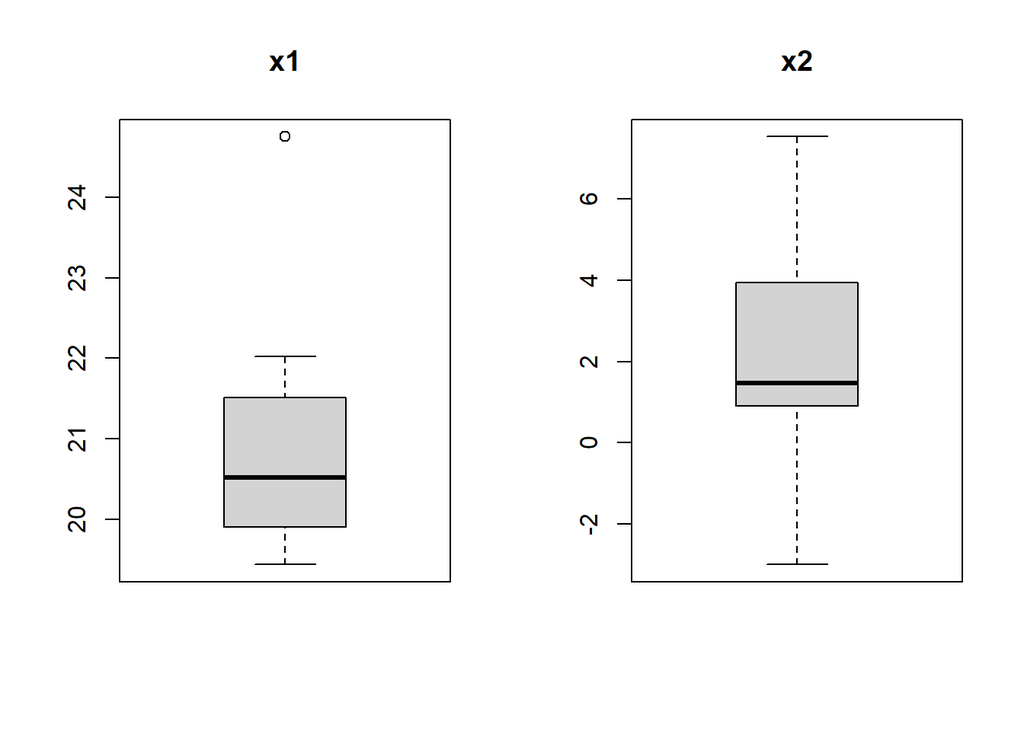

```r
data_sheet1 <- read_excel("Data praktikum 12.xlsx",sheet="data 100")
data_sheet2 <- read_excel("Data praktikum 12.xlsx",sheet="data 10")

x1 <- data_sheet2$x1
x2 <- data_sheet2$x2
y1 <- data_sheet1$y1
y2 <- data_sheet1$y2


par(mfrow=c(1,2))
boxplot(x1,main="x1")
boxplot(x2,main="x2")
```

## X1 ada satu outlier yang terlihat, kemudian jika diperhatikan kembali, maka hasilnya cenderung menjulur ke kanan

### rosnerTest

```r
ros_x1 <- rosnerTest(x1,k=4)
allstat_ros <- ros_x1$all.stats
vec_x1_ros <- x1[allstat_ros[allstat_ros['Outlier']==TRUE,'Obs.Num']]
vec_x1_ros
```

```
## [1] 24.75342
```

## X2

```r
ros_x2 <- rosnerTest(x2,k=5)
allstat_ros <- ros_x2$all.stats
vec_x2_ros <- x2[allstat_ros[allstat_ros['Outlier']==TRUE,'Obs.Num']]
vec_x2_ros
```

```
## [1]  7.526452 -2.991378  4.533626  3.939124
```

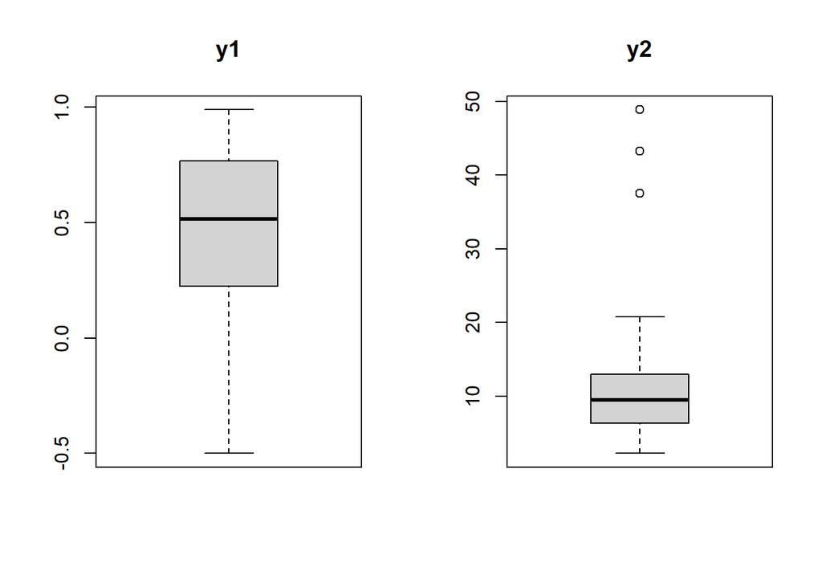

```r
par(mfrow=c(1,2))
boxplot(y1,main="y1")
boxplot(y2,main="y2")
```

## Y1

```r
ros_y1 <- rosnerTest(y1,k=5)
allstat_ros <- ros_y1$all.stats
vec_y1_ros <- y1[allstat_ros[allstat_ros['Outlier']==TRUE,'Obs.Num']]
vec_y1_ros
```

```
## numeric(0)
```

## Y2

```r
ros_y2 <- rosnerTest(y1,k=5)
allstat_ros <- ros_y1$all.stats
vec_y2_ros <- y1[allstat_ros[allstat_ros['Outlier']==TRUE,'Obs.Num']]
vec_y2_ros
```

```
## numeric(0)
```

# Nomor 2

## X1

### Trimmed Mean

```r
mean(x1,trim = 0.05)
```

```
## [1] 21.02891
```

### Winsorzed Mean

```r
winsor.mean(x1, trim=0.05)
```

```
## [1] 20.92647
```

### M-Estimators

#### huber

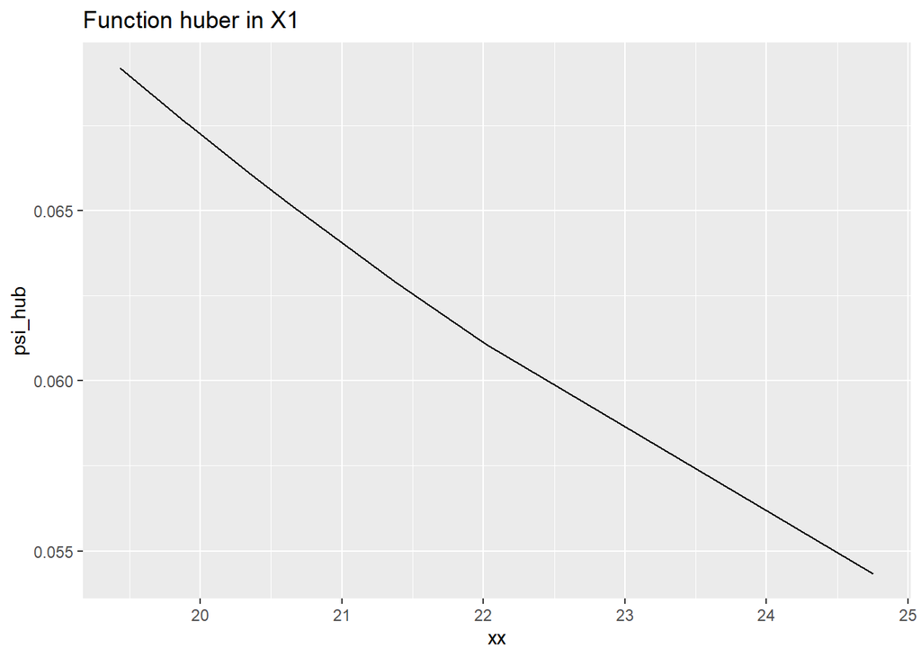

```r
fun_hub_x1 <- psi.huber(x1, k = 1.345, deriv = 0)
df_hub_x1 <- data.frame(xx=x1,psi_hub=fun_hub_x1)
ggplot(df_hub_x1,aes(xx,psi_hub)) +
  geom_line() + ggtitle("Function huber in X1")
```

```r
M_es_hub <- huber(x1, k = 1.345)
M_es_hub$mu
```

```
## [1] 20.77871
```

## X2

### Trimmed Mean

```r
mean(x2,trim = 0.05)
```

```
## [1] 2.020437
```

### Winsorzed Mean

```r
winsor.mean(x2, trim=0.05)
```

```
## [1] 2.045956
```

### M-Estimators

#### huber

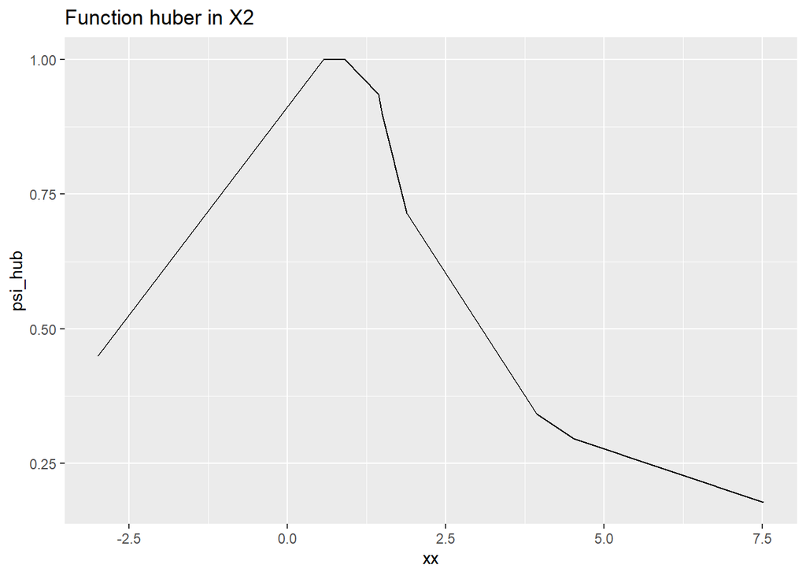

```r
fun_hub_x2 <- psi.huber(x2, k = 1.345, deriv = 0)
df_hub_x2 <- data.frame(xx=x2,psi_hub=fun_hub_x2)
ggplot(df_hub_x2,aes(xx,psi_hub)) +
  geom_line() + ggtitle("Function huber in X2")
```

```r
M_es_hub <- huber(x2, k = 1.345)
M_es_hub$mu
```

```
## [1] 1.687373
```

## Y1

### Trimmed Mean

```r
mean(y1,trim = 0.05)
```

```
## [1] 0.5074825
```

### Winsorzed Mean

```r
winsor.mean(y1, trim=0.05)
```

```
## [1] 0.504838
```

### M-Estimators

#### huber

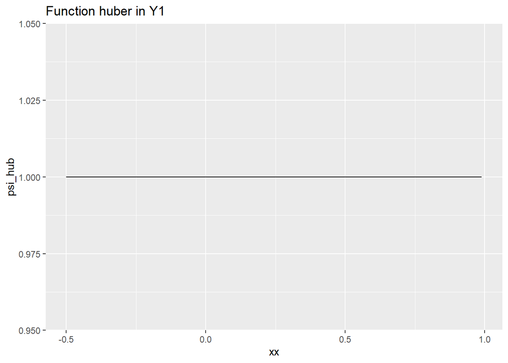

```r
fun_hub_y1 <- psi.huber(y1, k = 1.345, deriv = 0)
df_hub_y1 <- data.frame(xx=y1,psi_hub=fun_hub_y1)
ggplot(df_hub_y1,aes(xx,psi_hub)) +
  geom_line() + ggtitle("Function huber in Y1")
```

```r
M_es_hub <- huber(y1, k = 1.345)
M_es_hub$mu
```

```
## [1] 0.5045575
```

## Y2

### Trimmed Mean

```r
mean(y2,trim = 0.05)
```

```
## [1] 9.939848
```

### Winsorzed Mean

```r
winsor.mean(y2, trim=0.05)
```

```
## [1] 10.11176
```

### M-Estimators

#### huber

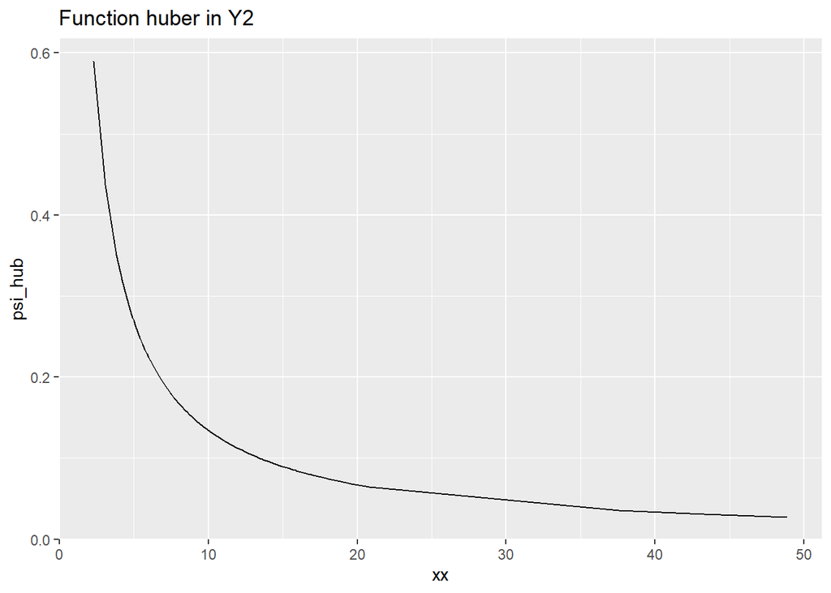

```r
fun_hub_y2 <- psi.huber(y2, k = 1.345, deriv = 0)
df_hub_y2 <- data.frame(xx=y2,psi_hub=fun_hub_y2)
ggplot(df_hub_y2,aes(xx,psi_hub)) +
  geom_line() + ggtitle("Function huber in Y2")
```

```r
M_es_hub <- huber(y2, k = 1.345)
M_es_hub$mu
```

```
## [1] 9.890736
```

# Nomor 3

###### IQR

Berdasarkan [dari link ini](https://web.ipac.caltech.edu/staff/fmasci/home/astro_refs/RobustEstimators.pdf), Maka Sebelum kita menentukan nilai IQR dari suatu data, maka kita lihat distribusi apa yang cocok dengan data tersebut

## X1

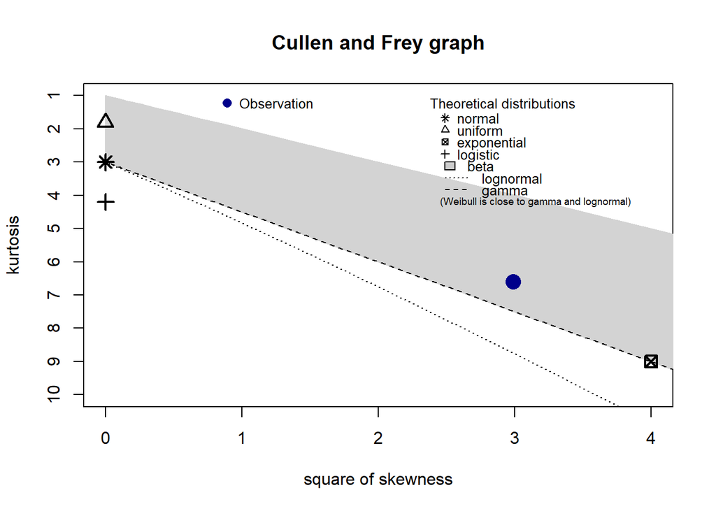

```
## summary statistics
## ------
## min:  19.4353   max:  24.75342
## median:  20.51857
## mean:  21.02891
## estimated sd:  1.537735
## estimated skewness:  1.728735
## estimated kurtosis:  6.605395
```

```r
descdist(x1)
```

Dengan Menggunakan Graph Cullen and Frey graph, Maka kemungkinan distribusi x1 antara beta dan gamma. Tetapi dikarenakan error menggunakan Beta, maka bisa kita cek gamma. Tetapi sebelum itu, kita gunakan qqplot dahulu yaaa dengan distibusi normal terlebih dahulu

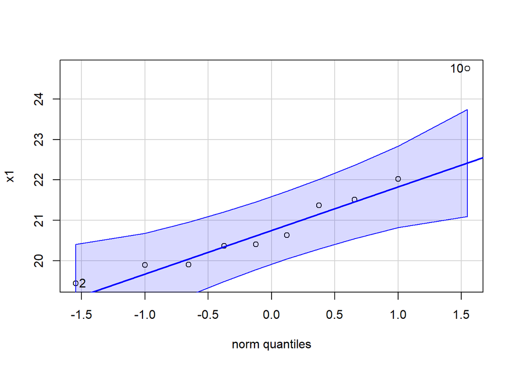

```
## [1] 10  2
```

```r
# qqnorm(x1, pch = 1, frame = FALSE)
# qqline(x1, col = "steelblue", lwd = 2)
qqPlot(x1)
```

Setelah diperhatikan, Sebenarnya distribusi ini mendekati normal, tetapi dikarenakan adanya outlier, maka jika kita test dengan ks.test

```r
fit_x1 <- fitdist(x1,"norm")
summary(fit_x1)
```

```
## Fitting of the distribution ' norm ' by maximum likelihood
## Parameters :
##       estimate Std. Error
## mean 21.028911  0.4613204
## sd    1.458823  0.3262021
## Loglikelihood:  -17.96569   AIC:  39.93137   BIC:  40.53654
## Correlation matrix:
##      mean sd
## mean    1  0
## sd      0  1
```

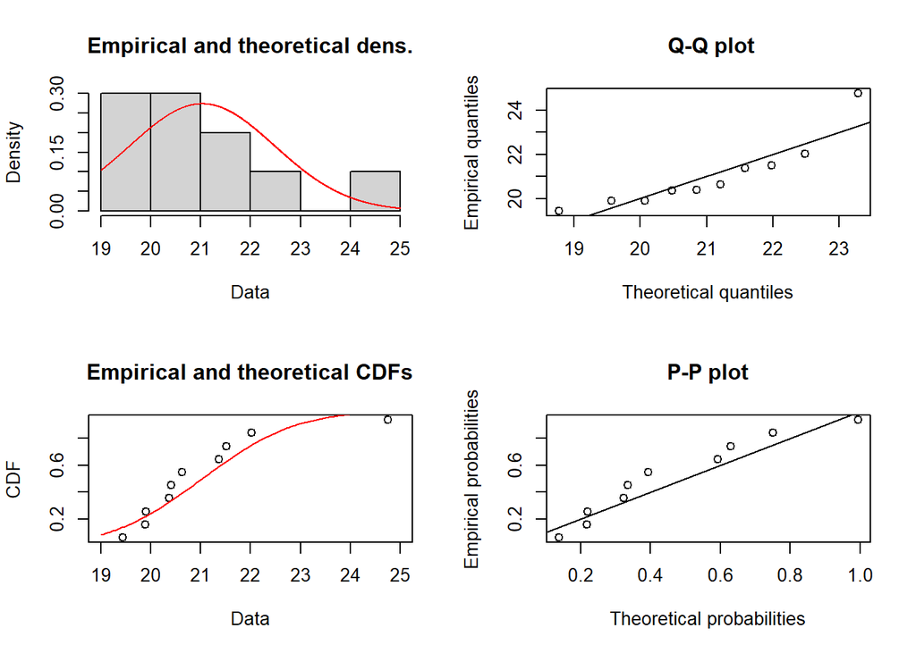

```r
plot(fit_x1)
```

```r
ks.test(x1,"pnorm",mean=21.028911,sd=1.458823)
```

```
##
##  One-sample Kolmogorov-Smirnov test
##
## data:  x1
## D = 0.20699, p-value = 0.7123
## alternative hypothesis: two-sided
```

```r
shapiro.test(x1)
```

```
##
##  Shapiro-Wilk normality test
##
## data:  x1
## W = 0.83965, p-value = 0.0437
```

jika diperhatikan, jika ks.test normal, sedangkan shapiro-wilk test ini tidak normal, untuk p-value shapiro-wilk ini, mendekati normal, meskipun mendekati p-value.

**X1 itu adalah Distribusi Normal (mean=21.028911,sd=1.458823)**

## X2

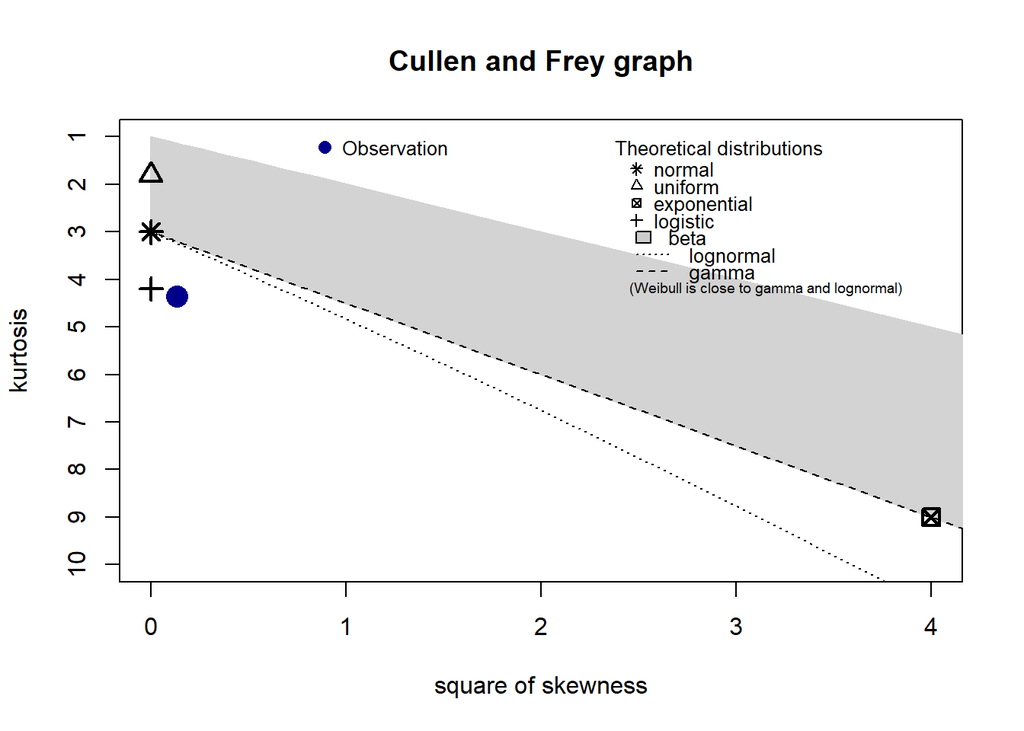

```
## summary statistics
## ------
## min:  -2.991378   max:  7.526452
## median:  1.468013
## mean:  2.020437
## estimated sd:  2.802018
## estimated skewness:  0.3648262
## estimated kurtosis:  4.365285
```

```r
descdist(x2)
```

Disini, banyak sekali kemungkinan yaaa. jika diperhatikan, distribusinya ada logistic , atau mungkin lognormal. Kita cek qqplot yang logistic yaaa

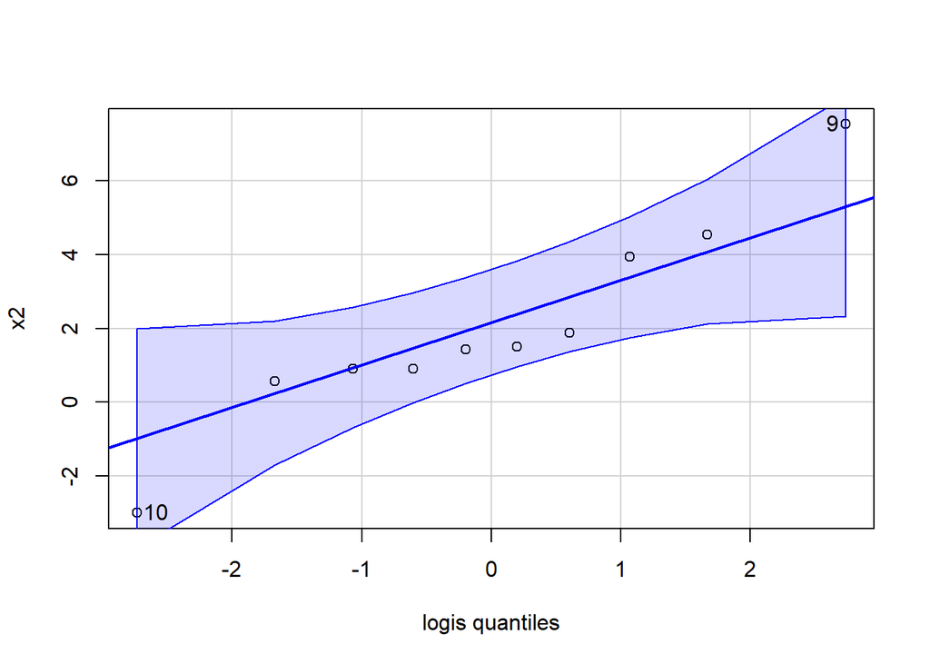

```
## [1]  9 10
```

```r
qqPlot(x2,"logis")
```

```r
fit_x2 <- fitdist(x2,"logis")
fit_x2
```

```
## Fitting of the distribution ' logis ' by maximum likelihood
## Parameters:
##          estimate Std. Error
## location 1.882585  0.7817310
## scale    1.446234  0.3932554
```

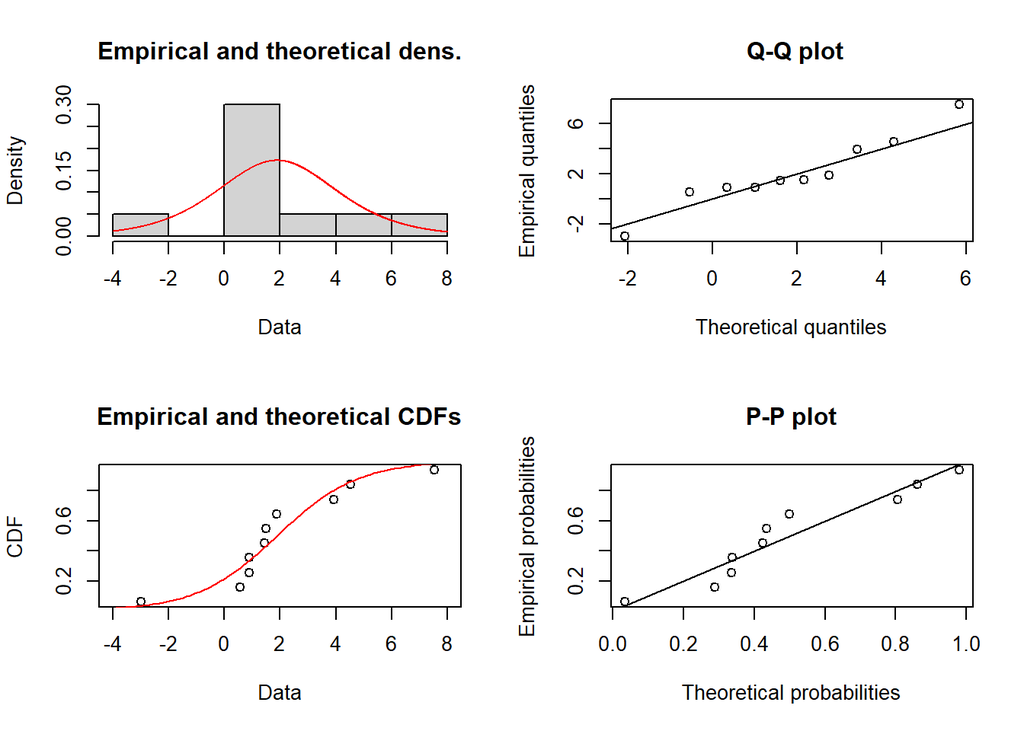

```r
plot(fit_x2)
```

Bisa dilihat bahwa sebenarnya data ini merupakan distribusi logistik

```r
ks.test(x2,"plogis",location=1.882585,scale=1.446234)
```

```
##
##  One-sample Kolmogorov-Smirnov test
##
## data:  x2
## D = 0.19993, p-value = 0.7491
## alternative hypothesis: two-sided
```

```r
shapiro.test(x2)
```

```
##
##  Shapiro-Wilk normality test
##
## data:  x2
## W = 0.93129, p-value = 0.4607
```

**X2 itu adalah Distribusi Logistik (location=1.882585,scale=1.446234)**

## Y1

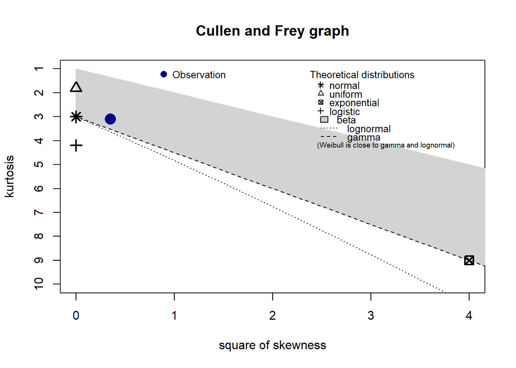

```
## summary statistics
## ------
## min:  -0.499999   max:  0.9888917
## median:  0.5144103
## mean:  0.4906979
## estimated sd:  0.3482005
## estimated skewness:  -0.5900393
## estimated kurtosis:  3.094567
```

```r
descdist(y1)
```

Bisa diperhatikan, bahwa Asumsi distribusi uniform, normal , gamma, dan logistik. berarti kita cek yahhh 4 distribusi, berarti kita cek yaaa dahulu uniform

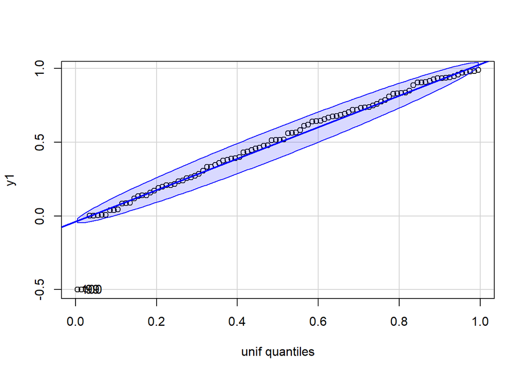

```
## [1] 100  99
```

```r
qqPlot(y1,distribution="unif")
```

```r
fit_y1 <- fitdist(y1,"unif")
fit_y1
```

```
## Fitting of the distribution ' unif ' by maximum likelihood
## Parameters:
##       estimate Std. Error
## min -0.4999990         NA
## max  0.9888917         NA
```

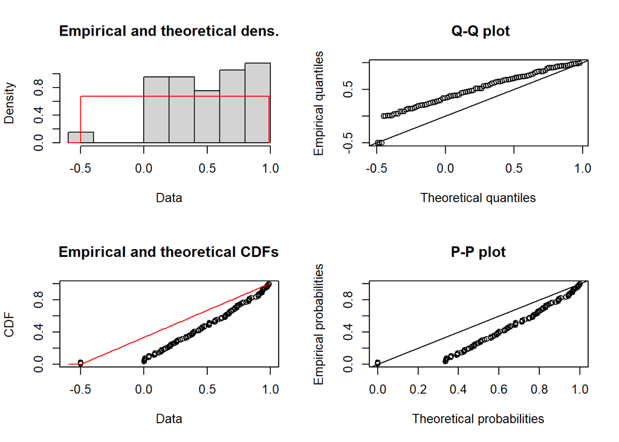

```r
plot(fit_y1)
```

```r
ks.test(y1,"punif")
```

```
##
##  One-sample Kolmogorov-Smirnov test
##
## data:  y1
## D = 0.072115, p-value = 0.6758
## alternative hypothesis: two-sided
```

```r
shapiro.test(y1)
```

```
##
##  Shapiro-Wilk normality test
##
## data:  y1
## W = 0.94574, p-value = 0.0004397
```